# Data_Challenge_Postmates_Vikrant_Patil

Jumpman23 - New Market Analysis

Vikrant Patil

1. Loading the data and preprocessing
1. Data Integrity Issues

   2.1.Issue 1 - Checking for NA values

   2.2.Issue 2 - Checking for time consistency

   2.3.Issue 3 - Checking for Duplicates

   2.4.Issue 4 - Checking for item categorization

   2.5.Issue 5 - Pickup Categorization
1. Analysis of New York market

   3.1.Daily count of customers ordering from Jumpman23

   3.2.How many items are the customers ordering at once

   3.3.What are the different modes of deliveries used by Jumpmen

   3.4.Which are the Top 10 pickup places from where the customers order?

   3.5.What type of food is ordered the most by the customers?

   3.6.How long it takes for the order to be completed?

   3.7.How long it takes for the Jumpman to reach the dropoff location?

   3.8.What are the busiest hours for Jumpman23 in New York?

   3.9.What are the busiest days for Jumpman23 in New York?

   3.10.heatmap to compare day of week and time of day

   3.11.Is delivery time getting affected by peak hours?

   3.12.Understanding the pickup and dropoff locations with help of maps

## Loading the data, viewing and checking the data types of columns

**Loading the required libraries**

```python
import pandas as pd
import numpy as np
import matplotlib.pyplot as plt
import seaborn as sns
```

```python
df = pd.read_csv('analyze_me.csv')
```

```python
df.head()
```

|  | delivery_id | customer_id | jumpman_id | vehicle_type | pickup_place | place_category | item_name | item_quantity | item_category_name | how_long_it_took_to_order | pickup_lat | pickup_lon | dropoff_lat | dropoff_lon | when_the_delivery_started | when_the_Jumpman_arrived_at_pickup | when_the_Jumpman_left_pickup | when_the_Jumpman_arrived_at_dropoff |
| --- | --- | --- | --- | --- | --- | --- | --- | --- | --- | --- | --- | --- | --- | --- | --- | --- | --- | --- |
| 0 | 1457973 | 327168 | 162381 | van | Melt Shop | American | Lemonade | 1.0 | Beverages | 00:19:58.582052 | 40.744607 | -73.990742 | 40.752073 | -73.985370 | 2014-10-26 13:51:59.898924 | NaN | NaN | 2014-10-26 14:52:06.313088 |
| 1 | 1377056 | 64452 | 104533 | bicycle | Prince Street Pizza | Pizza | Neapolitan Rice Balls | 3.0 | Munchables | 00:25:09.107093 | 40.723080 | -73.994615 | 40.719722 | -73.991858 | 2014-10-16 21:58:58.65491 | 2014-10-16 22:26:02.120931 | 2014-10-16 22:48:23.091253 | 2014-10-16 22:59:22.948873 |
| 2 | 1476547 | 83095 | 132725 | bicycle | Bareburger | Burger | Bare Sodas | 1.0 | Drinks | 00:06:44.541717 | 40.728478 | -73.998392 | 40.728606 | -73.995143 | 2014-10-28 21:39:52.654394 | 2014-10-28 21:37:18.793405 | 2014-10-28 21:59:09.98481 | 2014-10-28 22:04:40.634962 |
| 3 | 1485494 | 271149 | 157175 | bicycle | Juice Press | Juice Bar | OMG! My Favorite Juice! | 1.0 | Cold Pressed Juices | NaN | 40.738868 | -74.002747 | 40.751257 | -74.005634 | 2014-10-30 10:54:11.531894 | 2014-10-30 11:04:17.759577 | 2014-10-30 11:16:37.895816 | 2014-10-30 11:32:38.090061 |
| 4 | 1327707 | 122609 | 118095 | bicycle | Blue Ribbon Sushi | Japanese | Spicy Tuna & Tempura Flakes | 2.0 | Maki (Special Rolls) | 00:03:45.035418 | 40.726110 | -74.002492 | 40.709323 | -74.015867 | 2014-10-10 00:07:18.450505 | 2014-10-10 00:14:42.702223 | 2014-10-10 00:25:19.400294 | 2014-10-10 00:48:27.150595 |

```python
df.shape
```

```
(5983, 18)
```

```python
df.dtypes
```

```
delivery_id                              int64
customer_id                              int64
jumpman_id                               int64
vehicle_type                            object
pickup_place                            object
place_category                          object
item_name                               object
item_quantity                          float64
item_category_name                      object
how_long_it_took_to_order               object
pickup_lat                             float64
pickup_lon                             float64
dropoff_lat                            float64
dropoff_lon                            float64
when_the_delivery_started               object
when_the_Jumpman_arrived_at_pickup      object
when_the_Jumpman_left_pickup            object
when_the_Jumpman_arrived_at_dropoff     object
dtype: object
```

**Converting all the date time objects to datetime format**

```python
df['when_the_delivery_started'] =  pd.to_datetime(df['when_the_delivery_started'], format='%Y-%m-%d %H:%M:%S.%f')
df['when_the_Jumpman_arrived_at_dropoff'] = pd.to_datetime(df['when_the_Jumpman_arrived_at_dropoff'], format='%Y-%m-%d %H:%M:%S.%f')
df['when_the_Jumpman_arrived_at_pickup'] = pd.to_datetime(df['when_the_Jumpman_arrived_at_pickup'], format='%Y-%m-%d %H:%M:%S.%f')
df['when_the_Jumpman_left_pickup'] = pd.to_datetime(df['when_the_Jumpman_left_pickup'], format='%Y-%m-%d %H:%M:%S.%f')
df['how_long_it_took_to_order']  = pd.to_datetime(df['how_long_it_took_to_order'], format='%H:%M:%S.%f')
```

### Data Integrity Issues

**In this section we investigate the data integrity issues.**

### Issue 1

We first start out by looking at the missing values.

**Checking for NA values**

```python
df.isna().sum()
```

```
delivery_id                               0
customer_id                               0
jumpman_id                                0
vehicle_type                              0
pickup_place                              0
place_category                          883
item_name                              1230
item_quantity                          1230
item_category_name                     1230
how_long_it_took_to_order              2945
pickup_lat                                0
pickup_lon                                0
dropoff_lat                               0
dropoff_lon                               0
when_the_delivery_started                 0
when_the_Jumpman_arrived_at_pickup      550
when_the_Jumpman_left_pickup            550
when_the_Jumpman_arrived_at_dropoff       0
dtype: int64
```

```python
inconsistent_NA_vals_in_columns = df.isnull().sum() * 100 / len(df)
missing_value_df = pd.DataFrame({'column_name': df.columns,
                                 'percent_missing': inconsistent_NA_vals_in_columns})
missing_value_df.sort_values('percent_missing', inplace=True, ascending= False)

missing_value_df
```

|  | column_name | percent_missing |
| --- | --- | --- |
| how_long_it_took_to_order | how_long_it_took_to_order | 49.222798 |
| item_name | item_name | 20.558248 |
| item_quantity | item_quantity | 20.558248 |
| item_category_name | item_category_name | 20.558248 |
| place_category | place_category | 14.758482 |
| when_the_Jumpman_left_pickup | when_the_Jumpman_left_pickup | 9.192713 |
| when_the_Jumpman_arrived_at_pickup | when_the_Jumpman_arrived_at_pickup | 9.192713 |
| pickup_lon | pickup_lon | 0.000000 |
| when_the_delivery_started | when_the_delivery_started | 0.000000 |
| dropoff_lon | dropoff_lon | 0.000000 |
| dropoff_lat | dropoff_lat | 0.000000 |
| delivery_id | delivery_id | 0.000000 |
| pickup_lat | pickup_lat | 0.000000 |
| customer_id | customer_id | 0.000000 |
| pickup_place | pickup_place | 0.000000 |
| vehicle_type | vehicle_type | 0.000000 |
| jumpman_id | jumpman_id | 0.000000 |
| when_the_Jumpman_arrived_at_dropoff | when_the_Jumpman_arrived_at_dropoff | 0.000000 |

From the above results we can see that most of the NA values are occurring in the 'how_long_it_took_to_order' column. This metric gives us an important estimate about how long the users generally take to order from Jumpman23. With nearly half of the values missing, we cannot use this column to perform any analysis.

```python
df['how_long_it_took_to_order'].min()
```

```
Timestamp('1900-01-01 00:01:22.997519')
```

On investigating this column further, we see that the minimum timestamp is of the year 1900. Hence we need to make sure we are collecting the data for this particular column properly. Also, most of the NA values are occuring in timestamp events which is another area to look into and understand the reasons behind the erroneous entries.

### Issue 2

**Checking if the event times recorded have any inconsistencies**

```python
inconsistent_delivery_started_gt_arrived_pickup_df= df[df.when_the_delivery_started > df.when_the_Jumpman_arrived_at_pickup]
len(inconsistent_delivery_started_gt_arrived_pickup_df)
```

```
501
```

In the above code, we can see that there are 501 data records where the time when delivery was started is greater than the time Jumpman arrived at the pickup place. This is another data integrity issue as the time when the delivery was started always has to be less than the time the Jumpman arrived at the pickup place.

```python
inconsistent_arrived_pickup_gt_left_pickup_df= df[df.when_the_delivery_started > df.when_the_Jumpman_left_pickup]
len(inconsistent_arrived_pickup_gt_left_pickup_df)
```

```
2
```

In the above code, we can see that there are 2 data records where the time when delivery was started is greater than the time Jumpman left the pickup place.

### Issue 3

**Checking for duplicate rows**

```python
inconsistent_duplicate_data = df[df.duplicated(subset=None, keep='first')]
len(inconsistent_duplicate_data)
```

```
16
```

From the above result, we can observe that there are 16 records where all the values are duplicated.

When we drill down a bit deeper into this problem, we observe that if a user wants to order the same item more than once, a new data record is getting created for it instead of only the item_quantity getting updated.

### Issue 4

**Checking the consistency of item names and item categories**

```python
inconsistent_df = df[df.groupby(['item_name'])['item_category_name'].transform('nunique') > 1][['item_name','item_category_name']]
sorted_col= inconsistent_df.sort_values('item_name')
sorted_col
```

|  | item_name | item_category_name |
| --- | --- | --- |
| 963 | Adult Grilled Cheese | Main |
| 5883 | Adult Grilled Cheese | Entrees |
| 5875 | Apple Pie | Pie |
| 1241 | Apple Pie | Desserts |
| 2018 | Arnold Palmer | Juice |
| 1128 | Arnold Palmer | Juice |
| 2452 | Arnold Palmer | Drinks |
| 5964 | Artic Char | Taiheiyo (Pacific Ocean) |
| 4609 | Artic Char | Taiseyo (Atlantic Ocean) |
| 4080 | Artic Char | Taiseyo (Atlantic Ocean) |
| 5273 | Assorted Dumplings | Bolied |
| 1803 | Assorted Dumplings | Franchia's Dumplings |
| 4129 | Avocado | Yasai (Vegetable Rolls) |
| 5369 | Avocado | Yasai (Vegetable Rolls) |
| 2707 | Avocado | Dosas and Uttapams |
| 2999 | Avocado | Roll |
| 3512 | Baba Ghannouj | Appetizers |
| 1614 | Baba Ghannouj | Dips |
| 2296 | Bacon | Sides |
| 5822 | Bacon | Breakfast (Sides) |
| 2506 | Bacon Cheeseburger | Burgers |
| 5036 | Bacon Cheeseburger | Burgers |
| 2796 | Bacon Cheeseburger | Burgers |
| 3668 | Bacon Cheeseburger | Main Menu |
| 5952 | Bacon Cheeseburger | Main Menu |
| 1914 | Bacon Cheeseburger | Main Menu |
| 5460 | Bacon Cheeseburger | Burgers |
| 2461 | Bacon Cheeseburger | Burgers |
| 1202 | Bagel | Bagel Sandwiches |
| 5331 | Bagel | Breakfast Sides |
| ... | ... | ... |
| 3701 | Tuna | Nigiri Sushi |
| 5358 | Tuna | Nigiri Sushi of Gari |
| 2148 | Tuna Salad | Salads (breakfast/lunch) |
| 5411 | Tuna Salad | Salads |
| 2023 | Tuna Salad | Salads |
| 2044 | Tuna Salad | Salad Sandwiches |
| 1505 | Tuna Salad | Salads (breakfast/lunch) |
| 2526 | Tuna Salad | Salads |
| 4748 | Tuna Salad | Salads (breakfast/lunch) |
| 1957 | Turkey Bacon | Breakfast Sides |
| 5535 | Turkey Bacon | Brunch Sides |
| 2598 | Unagi | Taiseyo (Atlantic Ocean) |
| 595 | Unagi | Sushi & Sashimi |
| 3365 | Unagi | Taiseyo (Atlantic Ocean) |
| 29 | Unagi | Taiseyo (Atlantic Ocean) |
| 2469 | Uni | Taiseyo (Atlantic Ocean) |
| 3719 | Uni | Taiseyo (Atlantic Ocean) |
| 3736 | Uni | Taiheiyo (Pacific Ocean) |
| 5334 | Uni | A La Carte Sushi or Sashimi |
| 1731 | Uni | Taiheiyo (Pacific Ocean) |
| 5284 | Uni | A La Carte Sushi & Sashimi |
| 5478 | Uni | Sushi & Sashimi |
| 2740 | Vegetable Dumplings | Bolied |
| 5768 | Vegetable Dumplings | Appetizers |
| 2986 | Watermelon | Desserts |
| 4777 | Watermelon | Cold Pressed Juices |
| 1389 | Whitefish Salad | Salads (Priced by 1/4, 1/2, whole lb) |
| 3231 | Whitefish Salad | Salads |
| 483 | Yellowtail | Nigiri Sushi of Gari |
| 4298 | Yellowtail | Nigiri Sushi |

1018 rows × 2 columns

We observe that there are a few items who appear under different item categories. This categories might be dependant on the pickup places but if not then it would be easier for us to understand how the ordering trend is if we could group them under just one category.

### Issue 5

Another issue which we observe in one of the graphs below is that the pickup categories could be defined clearly. We can see Burger as a dominant category which the customers order but it can be included under American. By doing this, American would be the most preferred pickup category.

Defining the item categories and pickup categories clearly and removing the current ambiguity would help us to understand how we are performing in this new market.

## Analysis of how Jumpman23 is doing in New York:

```python
df['delivery_started_date'] = pd.to_datetime(df['when_the_delivery_started']).dt.date
```

```python
tmp1 = df.groupby(['delivery_started_date', 'customer_id']).size().reset_index(name='counts')
```

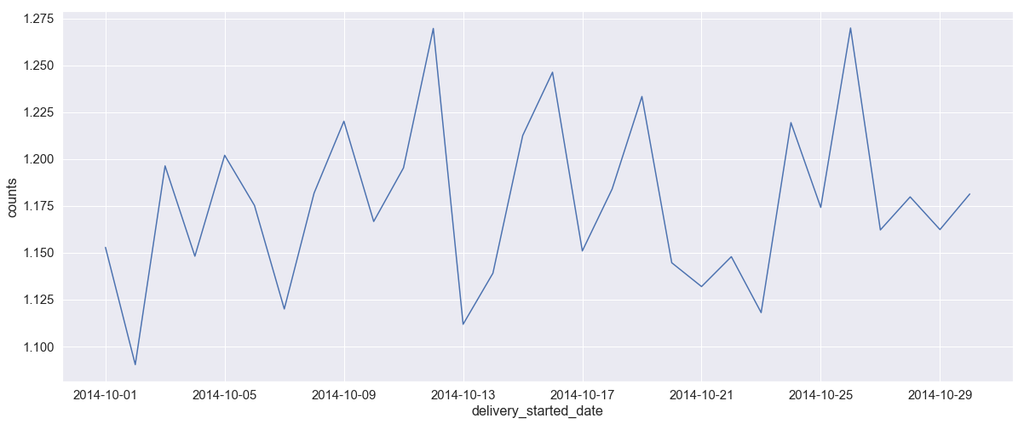

```python
plt.figure(figsize=(20,8))
sns.set(font_scale=1.35)

ax = sns.lineplot(x="delivery_started_date", y="counts", data=tmp1, ci=None)
```

### How many items are the customers ordering at once

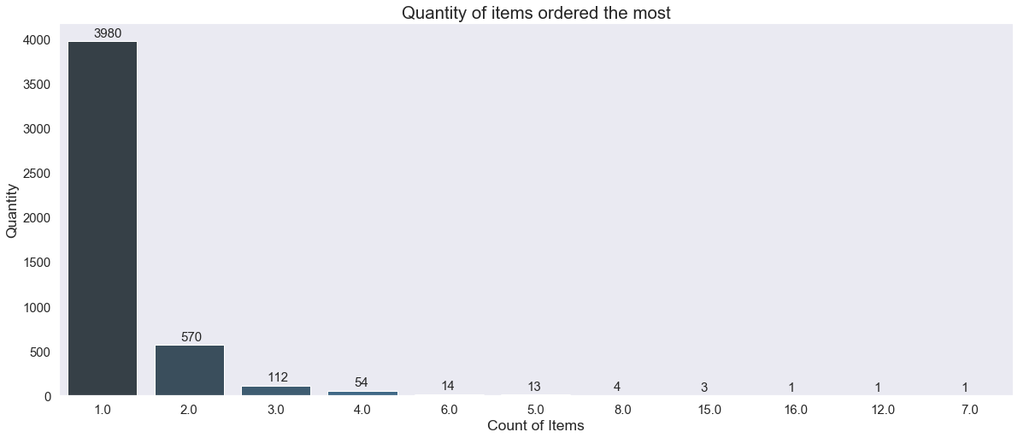

```python
plt.figure(figsize=(20,8))
sns.set(font_scale=1.35)


ax = sns.countplot(x="item_quantity", data=df, palette="Blues_d", order = df.item_quantity.value_counts().index)

ax.grid(False)
plt.title('Quantity of items ordered the most', fontsize = 20.5)
plt.xlabel('Count of Items', fontsize = 17.5)
plt.ylabel('Quantity', fontsize = 17.5)

for p in ax.patches:
        ax.annotate('{:}'.format(p.get_height()),(p.get_x()+0.3, p.get_height()+50), fontsize = 15)
```

We can see that generally at once, the customers order just 1 item. But, we should also note that in a few cases a customer is ordering more than one item at the same time but the data gets recorded differently. This is one of the issues covered in the data integrity issues section.

### What are the different modes of deliveries used by Jumpmen

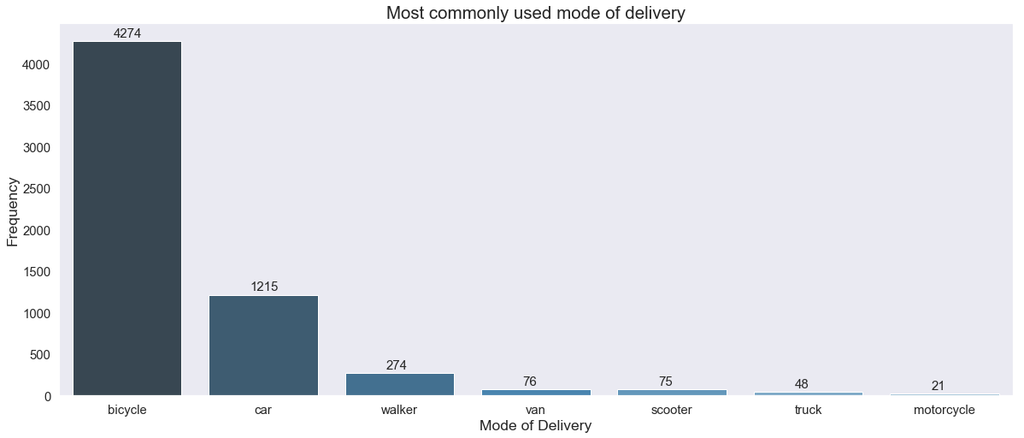

```python
plt.figure(figsize=(20,8))
sns.set(font_scale=1.35)


ax = sns.countplot(x="vehicle_type", data=df, palette="Blues_d", order = df.vehicle_type.value_counts().index)

ax.grid(False)
plt.title('Most commonly used mode of delivery', fontsize = 20.5)
plt.xlabel('Mode of Delivery', fontsize = 17.5)
plt.ylabel('Frequency', fontsize = 17.5)

for p in ax.patches:
        ax.annotate('{:}'.format(p.get_height()),(p.get_x()+0.3, p.get_height()+50), fontsize = 15)
```

We can see that bicycle is the preferred method of delivery

### Which are the Top 10 pickup places from where the customers order?

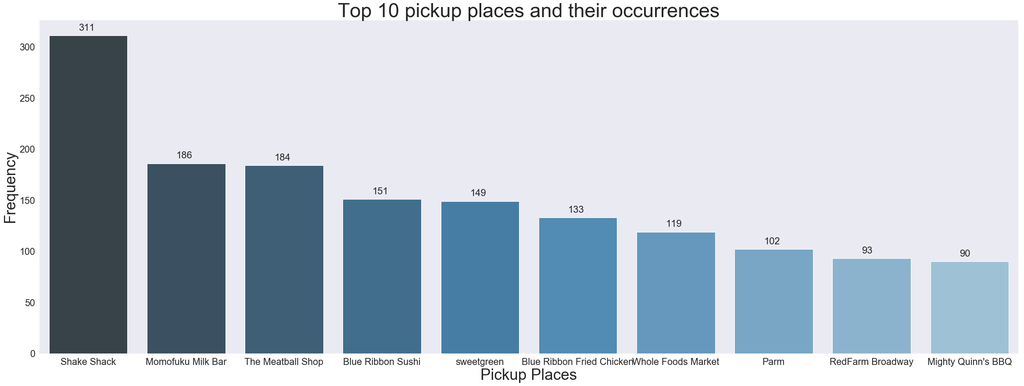

```python
plt.figure(figsize=(40,14))
sns.set(font_scale=1.95)

ax = sns.countplot(x="pickup_place", data=df, palette="Blues_d", order=df.pickup_place.value_counts().iloc[:10].index)

ax.grid(False)
plt.title('Top 10 pickup places and their occurrences', fontsize = 45)
plt.xlabel('Pickup Places', fontsize = 35)
plt.ylabel('Frequency', fontsize = 35)

for p in ax.patches:
        ax.annotate('{:}'.format(p.get_height()),(p.get_x()+0.3, p.get_height()+5), fontsize = 22)
```

### What type of food is ordered the most by the customers?

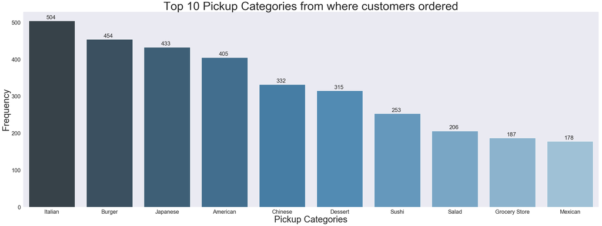

```python
plt.figure(figsize=(40,14))
sns.set(font_scale=1.95)

ax = sns.countplot(x="place_category", data=df, palette="Blues_d", order=df.place_category.value_counts().iloc[:10].index)

ax.grid(False)
plt.title('Top 10 Pickup Categories from where customers ordered', fontsize = 45)
plt.xlabel('Pickup Categories', fontsize = 35)
plt.ylabel('Frequency', fontsize = 35)

for p in ax.patches:
        ax.annotate('{:}'.format(p.get_height()),(p.get_x()+0.3, p.get_height()+5), fontsize = 22)
```

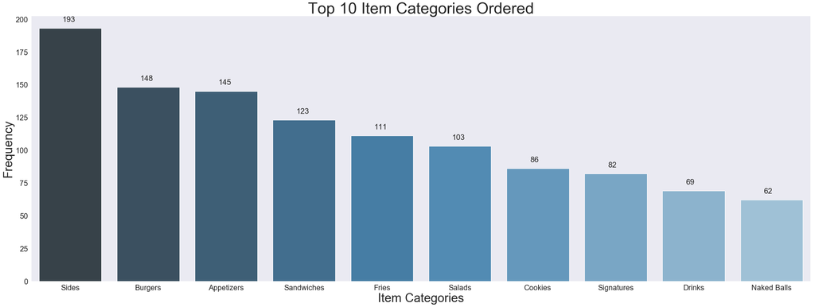

```python
plt.figure(figsize=(40,14))
sns.set(font_scale=1.95)

ax = sns.countplot(x="item_category_name", data=df, palette="Blues_d", order=df.item_category_name.value_counts().iloc[:10].index)

ax.grid(False)
plt.title('Top 10 Item Categories Ordered', fontsize = 45)
plt.xlabel('Item Categories', fontsize = 35)
plt.ylabel('Frequency', fontsize = 35)

for p in ax.patches:
        ax.annotate('{:}'.format(p.get_height()),(p.get_x()+0.3, p.get_height()+5), fontsize = 22)
```

### How long it takes for the order to be completed?

**Here we are considering the time when the delivery is started to the time when the Jumpman reach the dropoff location**

```python
df['time_from_order_to_dropoff'] = df['when_the_Jumpman_arrived_at_dropoff'] - df['when_the_delivery_started']
```

```python
df['time_from_order_to_dropoff'] = df['time_from_order_to_dropoff'].dt.seconds/(60)
```

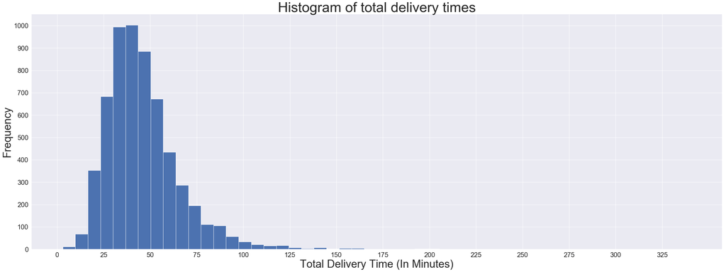

```python
plt.figure(figsize=(40, 14))
ax = plt.hist(df.time_from_order_to_dropoff, bins=50)

plt.title('Histogram of total delivery times', fontsize = 45)
plt.xlabel('Total Delivery Time (In Minutes)', fontsize = 35)
plt.ylabel('Frequency', fontsize = 35)

plt.xticks(np.arange(0.0, float(int(max(df.time_from_order_to_dropoff)) + 1.0), 25 ))
plt.yticks(np.arange(0.0, 1100, 100 ))
plt.tick_params(axis='x', which='minor')
```

We can see that most the delivery times range between 25 to 50 minutes

### How long it takes for the Jumpman to reach the dropoff location?

**Here we are considering the time when the Jumpman leaves the pickup location to the time when the Jumpman reach the dropoff location**

```python
df['time_when_jumpman_started_with_delivery'] = df['when_the_Jumpman_arrived_at_dropoff'] - df['when_the_Jumpman_left_pickup']
```

```python
df['time_when_jumpman_started_with_delivery'] = df['time_when_jumpman_started_with_delivery'].dt.seconds/(60)
```

```python
tmp3 = df['time_when_jumpman_started_with_delivery'].dropna()
```

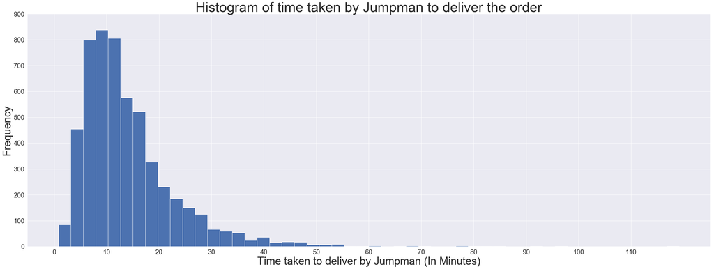

```python
plt.figure(figsize=(40, 14))
ax = plt.hist(tmp3, bins=50)

plt.title('Histogram of time taken by Jumpman to deliver the order', fontsize = 45)
plt.xlabel('Time taken to deliver by Jumpman (In Minutes)', fontsize = 35)
plt.ylabel('Frequency', fontsize = 35)

plt.xticks(np.arange(0.0, float(int(max(tmp3))+1.0), 10 ))
plt.yticks(np.arange(0.0, 1000, 100 ))
plt.tick_params(axis='x', which='minor')
```

### What are the busiest hours for Jumpman23 in New York?

```python
df['delivery_started_hour'] = df['when_the_delivery_started'].dt.hour
```

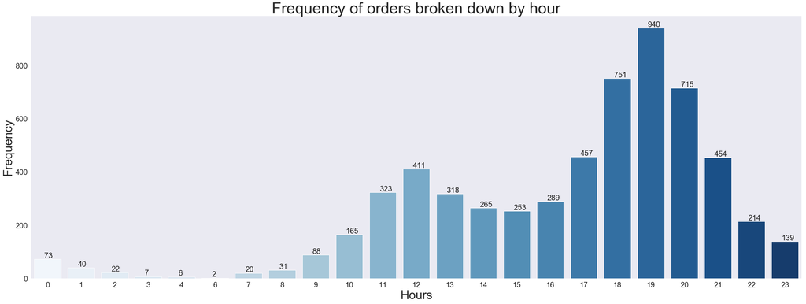

```python
plt.figure(figsize=(40,14))
sns.set(font_scale=1.95)

ax = sns.countplot(x="delivery_started_hour", data=df, palette="Blues")

ax.grid(False)
plt.title('Frequency of orders broken down by hour', fontsize = 45)
plt.xlabel('Hours', fontsize = 35)
plt.ylabel('Frequency', fontsize = 35)

for p in ax.patches:
        ax.annotate('{:}'.format(p.get_height()),(p.get_x()+0.3, p.get_height()+5), fontsize = 22)
```

We can observe that most of the deliveries are placed around 19:00 hours

### What are the busiest days for Jumpman23 in New York?

```python
df['delivery_started_day'] = df['when_the_delivery_started'].dt.day_name()
```

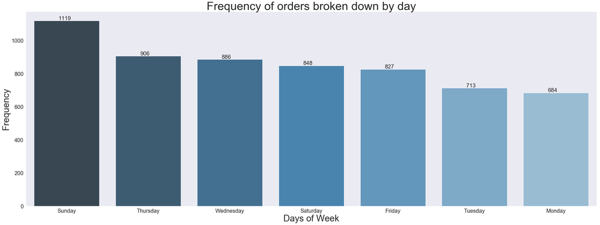

```python
plt.figure(figsize=(40,14))
sns.set(font_scale=1.95)

ax = sns.countplot(x="delivery_started_day", data=df, palette="Blues_d", order=df.delivery_started_day.value_counts().index)

ax.grid(False)
plt.title('Frequency of orders broken down by day', fontsize = 45)
plt.xlabel('Days of Week', fontsize = 35)
plt.ylabel('Frequency', fontsize = 35)

for p in ax.patches:
        ax.annotate('{:}'.format(p.get_height()),(p.get_x()+0.3, p.get_height()+5), fontsize = 22)
```

We can see that Sunday sees the most amount of orders

### A heatmap to compare day of week and time of day

```python
tmp4 = df.groupby(['delivery_started_day', 'delivery_started_hour']).size().reset_index(name='counts')
```

```python
day_ordered = [ 'Monday', 'Tuesday', 'Wednesday', 'Thursday', 'Friday', 'Saturday', 'Sunday']

tmp4['delivery_started_day'] = tmp4['delivery_started_day'].astype('category', categories=day_ordered, ordered=True)
```

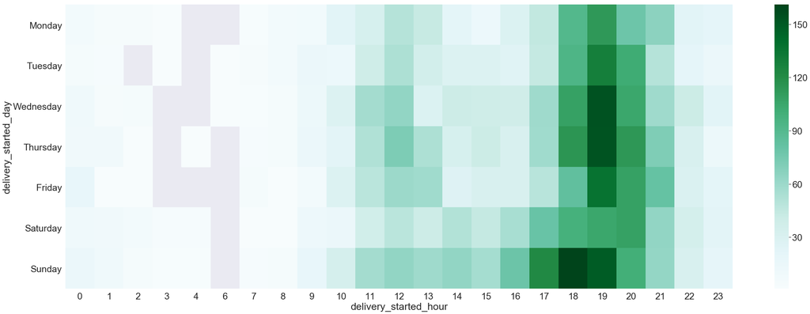

```python
plt.figure(figsize=(40,14))
sns.set(font_scale=2.25)

ax = pd.pivot_table(tmp4, values= 'counts', index=['delivery_started_day'], columns='delivery_started_hour')
sns.heatmap(ax, cmap="BuGn")
```

### Is delivery time getting affected by peak hours?

```python
df['delivery_by_jumpman_hour'] = df['when_the_Jumpman_left_pickup'].dt.hour

tmp5 = df[['time_when_jumpman_started_with_delivery','delivery_by_jumpman_hour']]
tmp5 = tmp5.dropna()
```

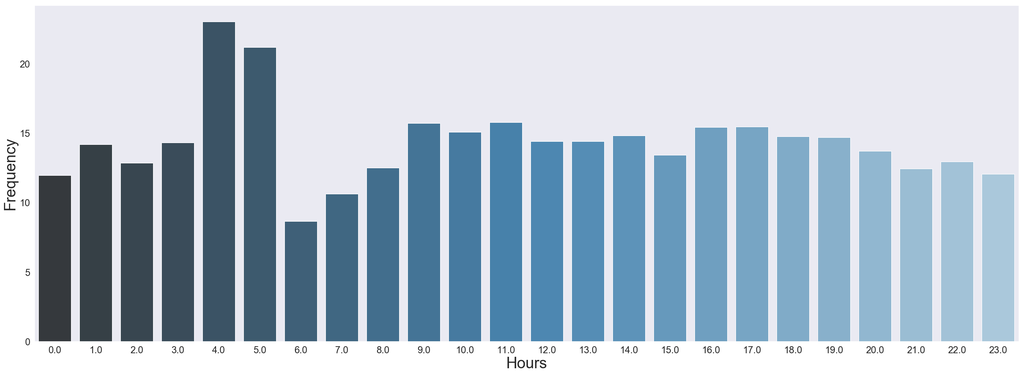

```python
plt.figure(figsize=(40,14))
sns.set(font_scale=1.95)

ax = sns.barplot(x="delivery_by_jumpman_hour", y ="time_when_jumpman_started_with_delivery" , data=tmp5, palette="Blues_d", ci=None)

ax.grid(False)
#plt.title('Frequency of orders broken down by hour', fontsize = 45)
plt.xlabel('Hours', fontsize = 35)
plt.ylabel('Frequency', fontsize = 35)
```

From the above graph we can see that the delivery times are not getting affected by busy hours. Early morning deliveries are generally a long time to get completed.

### Understanding the pickup and dropoff locations with help of maps

```python
import folium
from folium import plugins
```

```python
pickup = folium.Map([40.744607, -73.990742], zoom_start=10)
dropoff = folium.Map([40.744607, -73.990742], zoom_start=10)
```

```python
pickup_locations = df[['pickup_lat', 'pickup_lon']].as_matrix()

pickup.add_child(plugins.HeatMap(pickup_locations, radius=15))
pickup
```

[interactive chart not shown]

```python
dropoff_locations = df[['dropoff_lat', 'dropoff_lon']].as_matrix()

dropoff.add_child(plugins.HeatMap(dropoff_locations, radius=15))
dropoff
```

[interactive chart not shown]

From the above heatmaps we can see that the dropoff locations are a bit more spread out than that of the pickup locations. Most of the business is focussed in Manhattan area while there are a few hot spots in Brooklyn